# L25

# Legacy Code and Refactoring

## Characterization Tests

- Establish ground truth about how the app works today as a basis for coverage
  - Makes known behaviors Repeatable
  - Increase confidence that you’re not breaking anything
- When you don’t have tests and don’t understand the code
- **Do not try to make improvements at this stage**

### Integration-Level Characterization Tests

- Create the missing scenarios
- Watch / interview users while they use app to reproduce their workflows
- Do imperative/verbose scenarios now, improve on them later

### Unit / Module Characterization Tests

- Cheat: write tests to learn as you go
- Use the test to poke at the code and see what happens
  - Should initially return an error of some type
- Update expectation to reflect the return value

## Comments and Commits

- Comments tell what’s not obvious about the code rather than repeating what’s obvious
  - Example: code invariants, subtle problems that required unusual implementation, bug workarounds, strange corner cases
- If the developer needs to know this info while working on the code, put it in a comment

## Code Smells

- SOFA captures symptoms that often indicate code smells in a single method
  - Short
  - One thing (method only does one thing)
  - Few arguments
  - Abstraction is consistent (either what is to be done or how to do it)
- Single Level of Abstraction
  - Complex tasks ⟹ should be doing divide and conquer
  - For methods, top level method outlines high-level steps and delegates detail to helper methods
- Why lots of args are bad
  - Hard to get good testing
  - Hard to mock / stub while testing
  - Boolean arguments should be a yellow flag (usually should be two diff functions)
  - Similar groups of args can be extracted into a class

## Quantitative Code Complexity

- Look for hotspots ≙ multiple metrics throw red flags
- `metric_fu` gem gives metrics
- Take metrics with a grain of salt

### ABC Complexity

- Counts assignments ($A$), branches ($B$), and conditions ($C$)
- Score = $\sqrt{A^{2}+B^{2}+C^{2}}$
- Ideally ≤ 20 per method

### Cyclomatic Complexity

- How many paths there are through a block of code
- $E-N+2P$
  - $E\;\coloneqq\;\text{edges}$
  - $N\;\coloneqq\;\text{nodes}$
  - $P\;\coloneqq\;\text{connected components}$

## Method-Level Refactoring

- Take small steps
- Transform code to get rid of smells in steps
- Protect each step with tests
- Can increase lines of code but still reduce complexity
- Goals: get rid of code smells, Improve testability, reduce complexity
- Side effects: Eliminate bugs
- Should cause existing tests to fail
- Should result in necessary updates to test suite

## P&D Perspective on Software Maintenance

- Customers may pay software maintenance fee
- Development team is likely not the same as the original engineers
- Can have a separate maintenance manager
  - Like development manager
  - Estimate costs, maintain schedule, evaluate risks and overcome them
  - Recruits team
  - Document project maintenance plan
- Process
  1. Working in SW field ⟹ new releases can’t break features
  2. Customer collaboration ≙ work with customer to improve in next release vs meet contract spec
  3. Responding to change ≙ customer sends change requests; manager evaluates them
     - Change request forms have ticket tracking
- Change Control Board
  - Estimate cost/time per CR
  - QA team gives cost of testing for change request, including regression testing + new tests
  - Documentation teams gives cost of updating docs
  - Customer support group decides if urgent or workaround
  - Urgent ⟹ code needs to be fixed ASAP without other policies (customer-facing bug, security, competitor’s features)
- Emergencies can cascade and not have time to catch up
- Refactor time not usually built in so may not happen
  - Can sometimes run into issues where re-engineering is necessary
  - Builds up a lot of technical debt

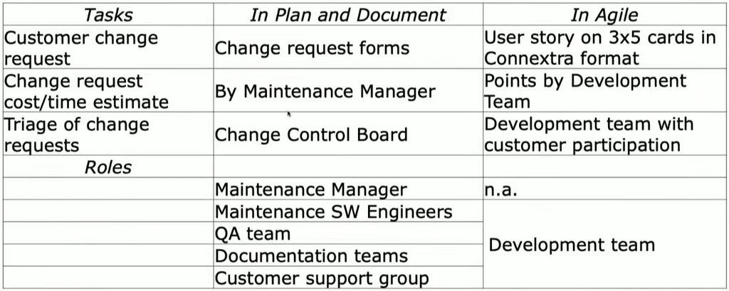